# Coronavirus v Čechách

## Přehled

Základní přehled (testy)

| Datum | Přírustkový počet testů | Kumulativní počet testů | Pozitivita testů (v %) |
| --- | --- | --- | --- |
| 2020-11-17 | 17503 | 2830704 | 24.26 |
| 2020-11-18 | 24341 | 2855045 | 22.66 |
| 2020-11-19 | 26409 | 2881454 | 24.50 |
| 2020-11-20 | 25495 | 2906949 | 22.79 |
| 2020-11-21 | 13308 | 2920257 | 23.97 |

Základní přehled (nákaza)

| Datum | Přírustkový počet nakažených | Kumulativní počet nakažených | Kumulativní počet vyléčených | Kumulativní počet úmrtí |
| --- | --- | --- | --- | --- |
| 2020-11-17 | 4246 | 469766 | 392754 | 6707 |
| 2020-11-18 | 5516 | 475282 | 393299 | 6844 |
| 2020-11-19 | 6470 | 481752 | 394089 | 6965 |
| 2020-11-20 | 5810 | 487562 | 394764 | 7056 |
| 2020-11-21 | 3190 | 490752 | 394933 | 7147 |

Aktivní případy: `89536`

Aktuálně hospitalizovaní: `5421`

Podíl nakažených s těžkým průběhem: `6.05`%

Smrtnost: `1.46`%

# SIR MODELY

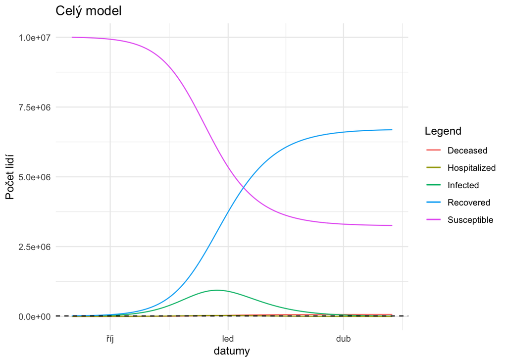

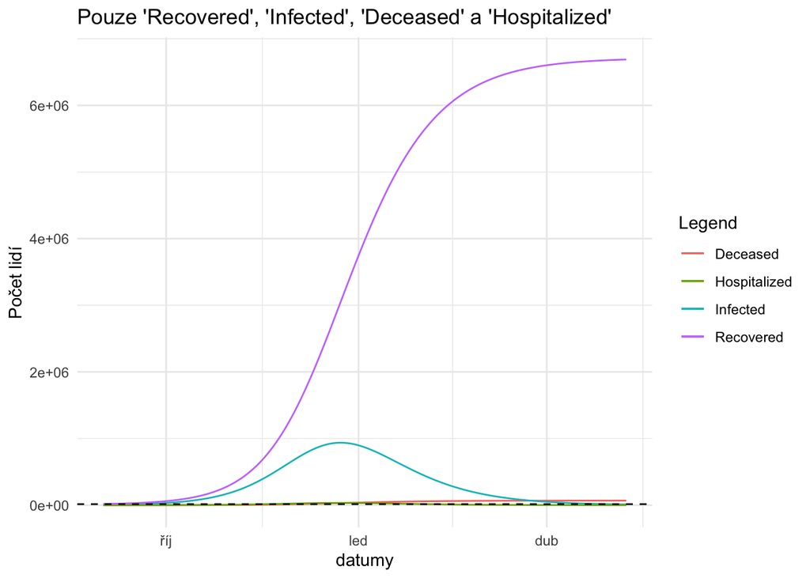

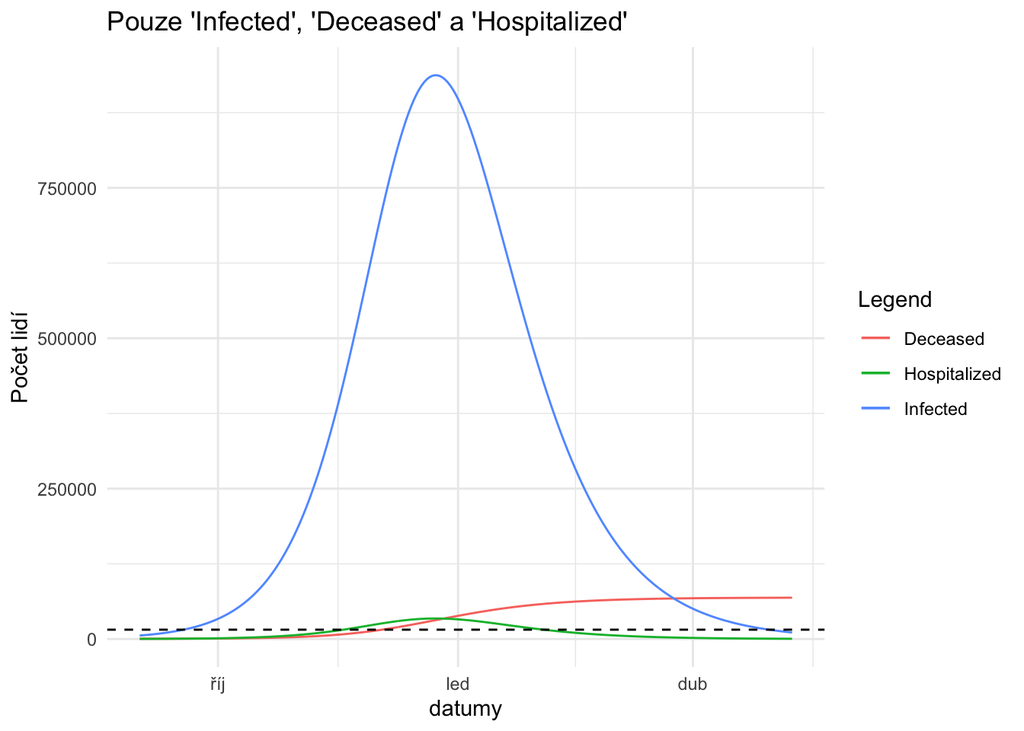

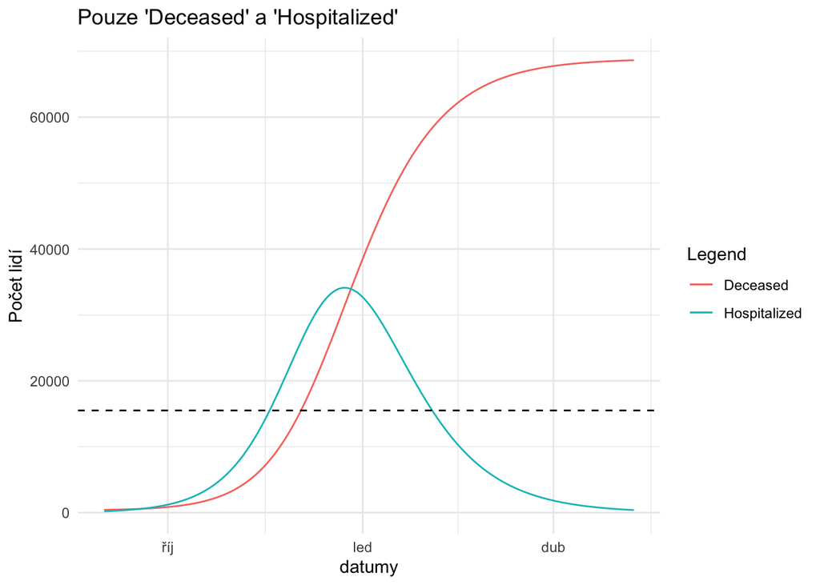

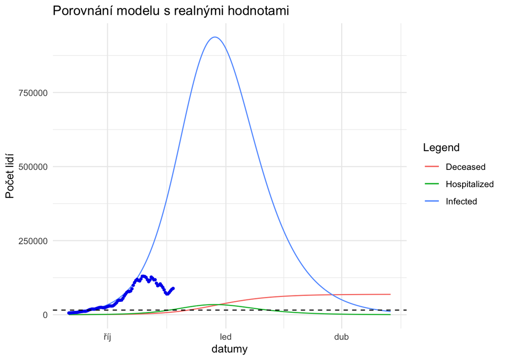

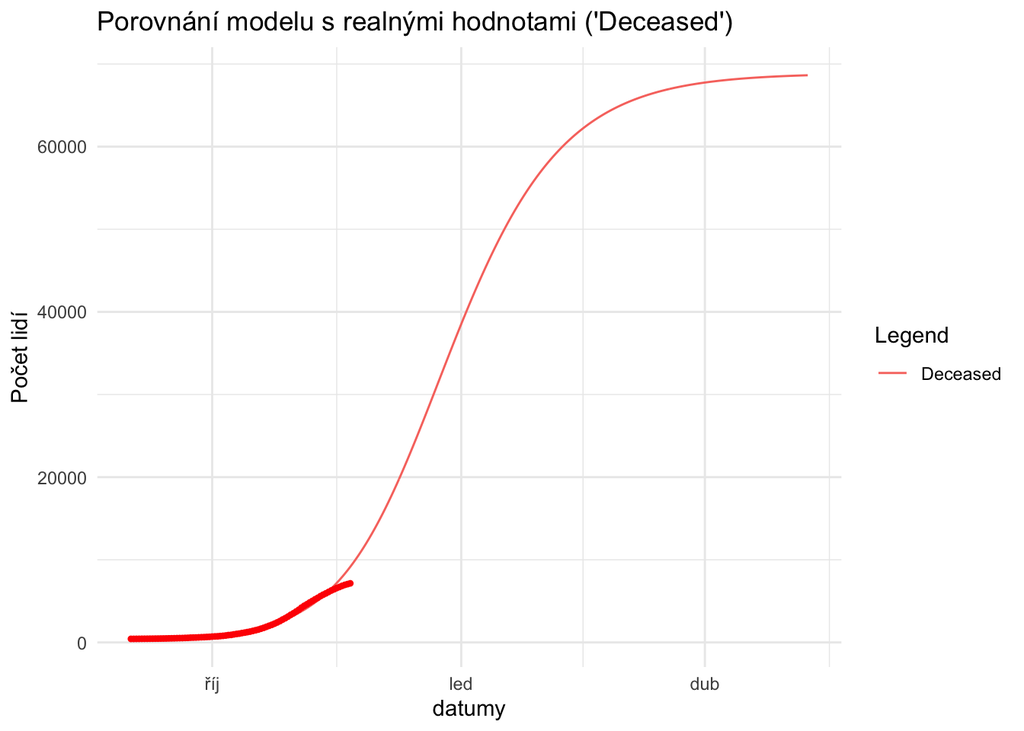

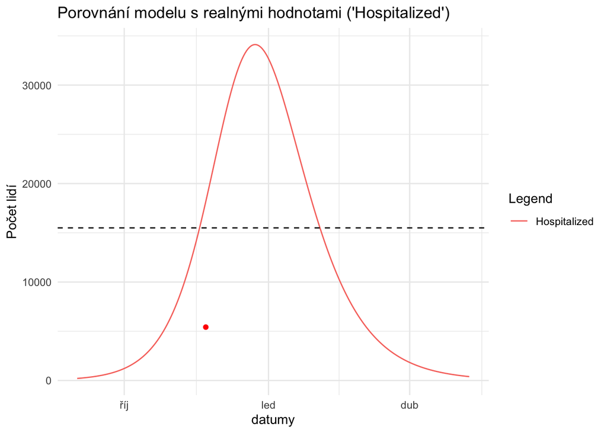

## Informace

`Peak nastane dne 2020-12-23 s počtem nakažených rovnu 937231 a aktuálním počtem hospitalizovných v nemocnicích 34115 lidí.`

`Kapacita nemocnic, která je stanovena na 15500 lůžek, bude při momentálním trendu překročena dne 2020-11-19`

`Celkově Covid-19 prodělá 6688258`

`Počet umrtí se zastaví na čísle 68637`

`Momentální hodnota rho je 1.682`

# Základní statistiky

## Testy

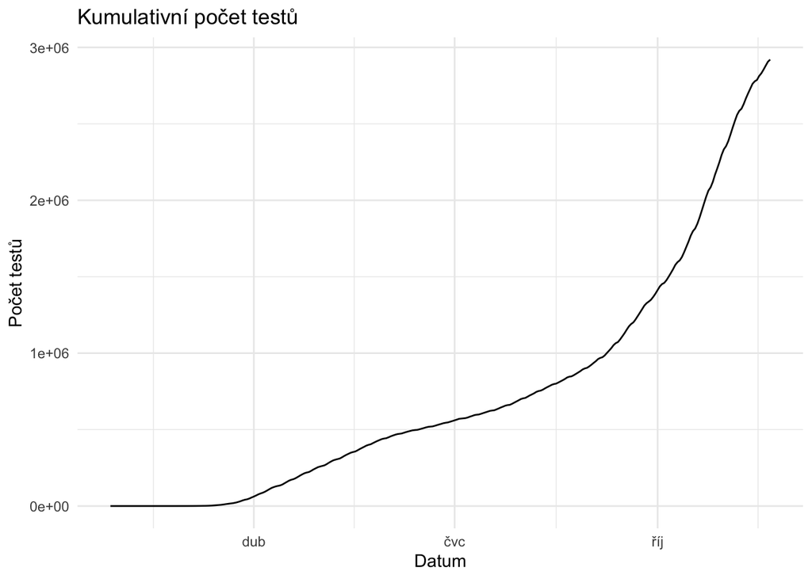

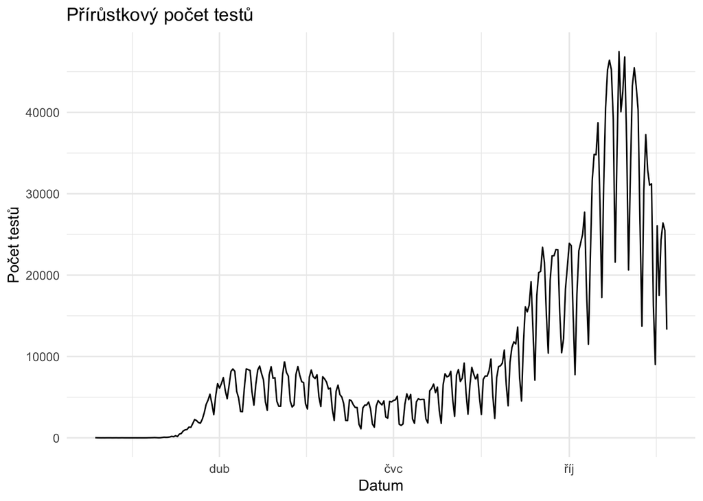

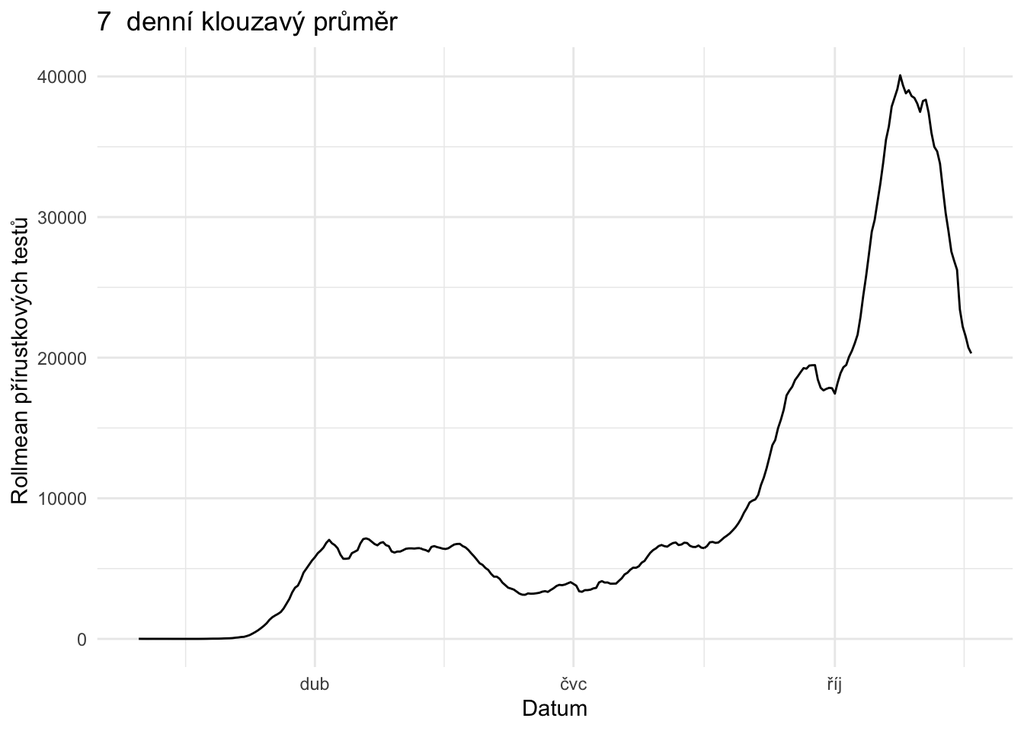

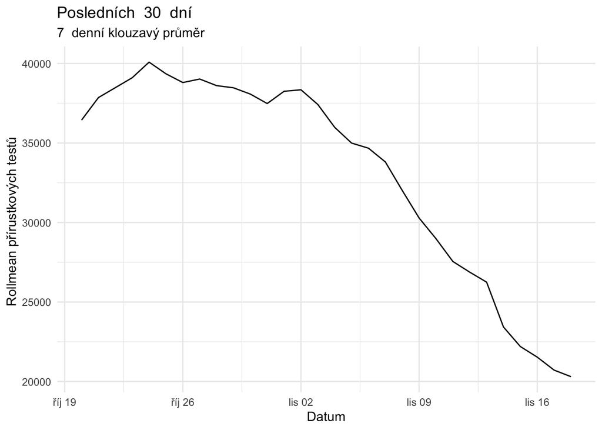

## Pozitivní případy

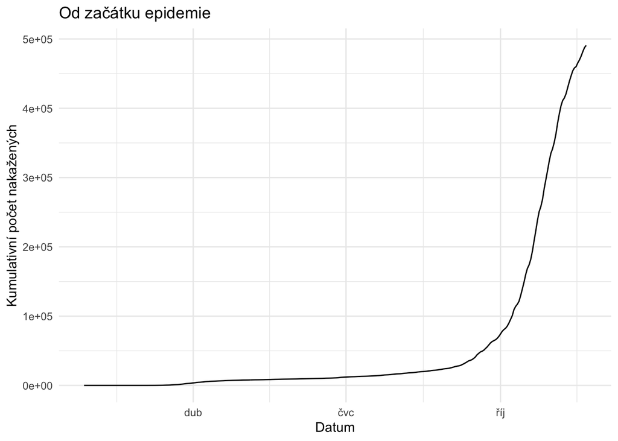

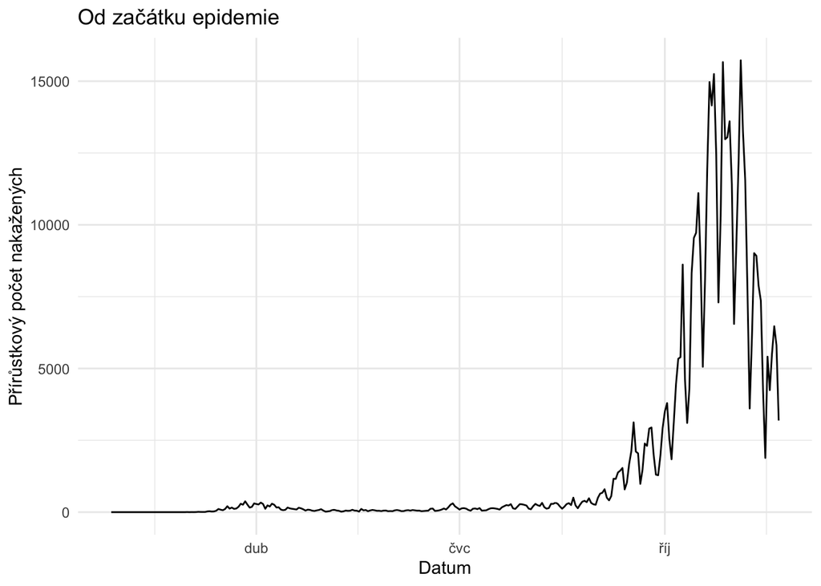

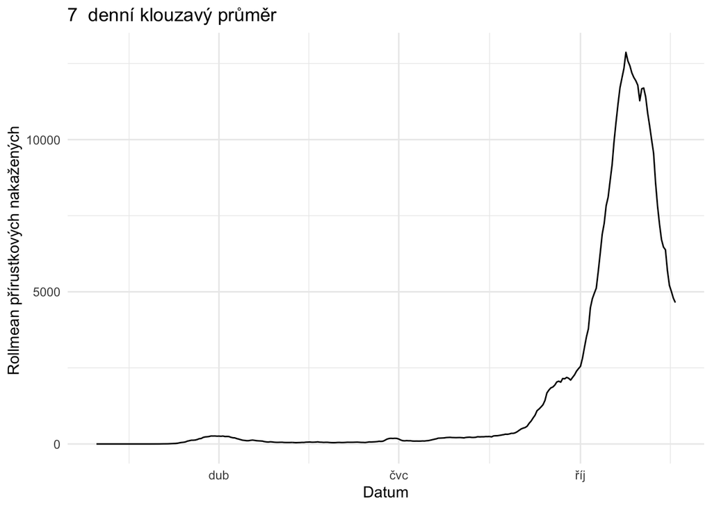

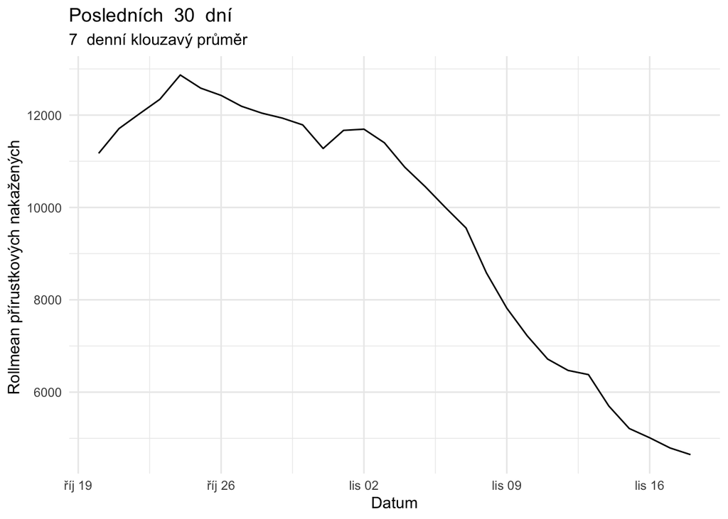

## Podíl pozitivních testů

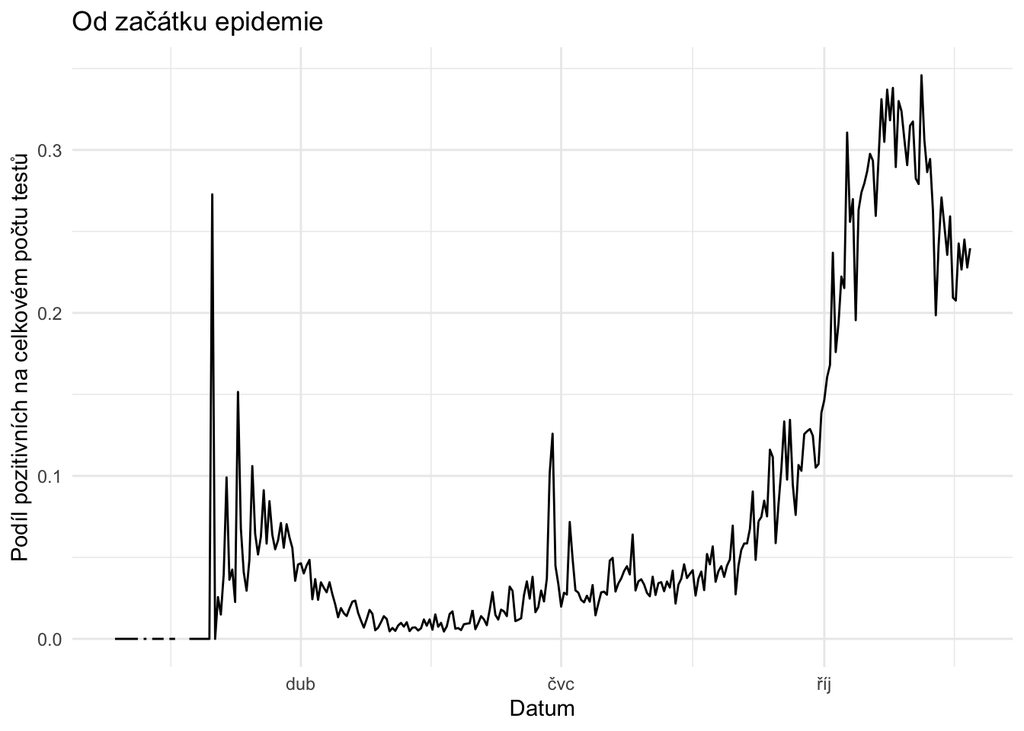

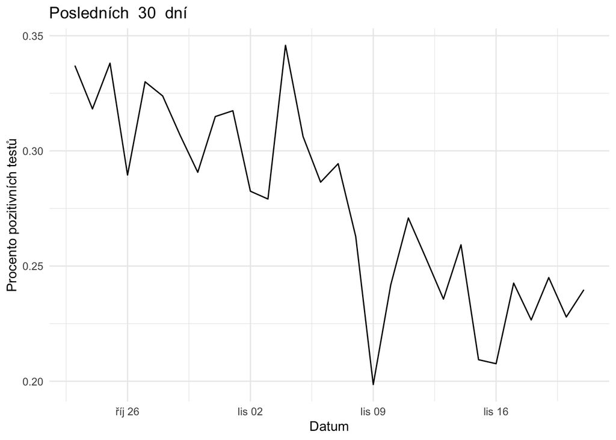

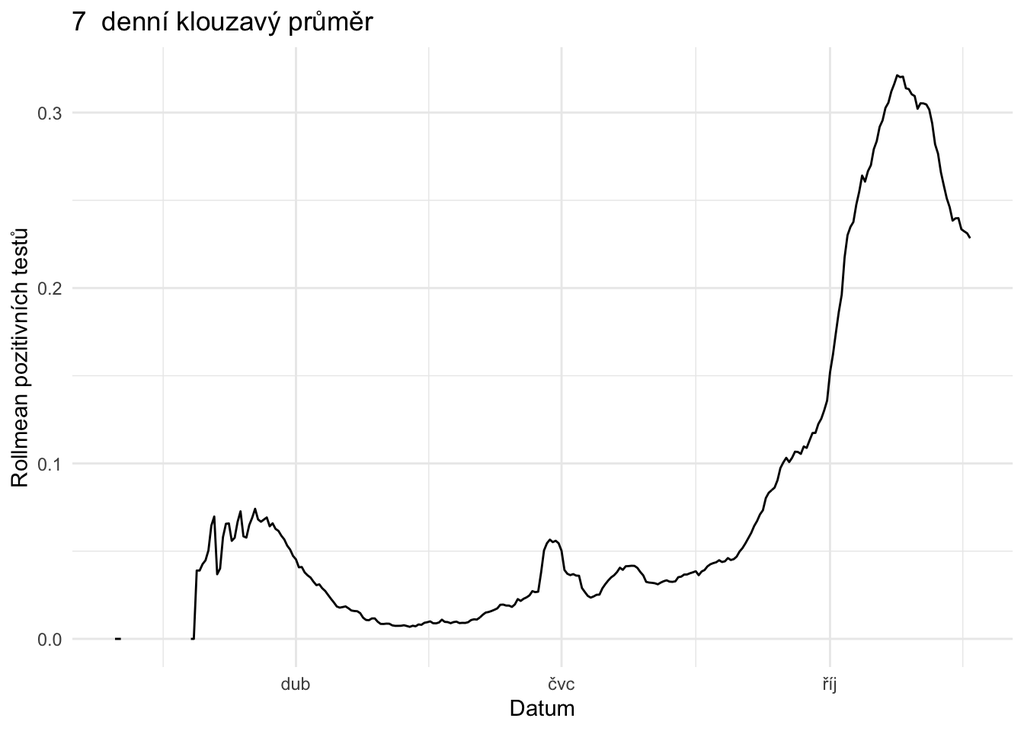

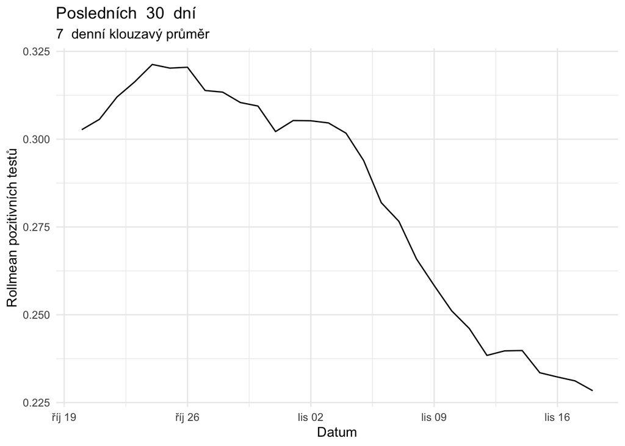

Podíl pozitivních testů na celkovém počtu od začátku epidemie je `16.805` %.

Podíl pozitivních testů na celkovém počtu za posledních 30 dní je `28.428` %.

# Modely

## Linearní model

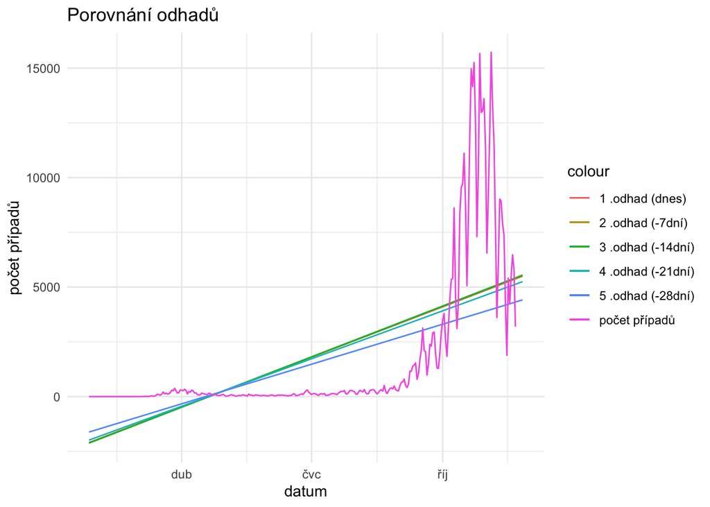

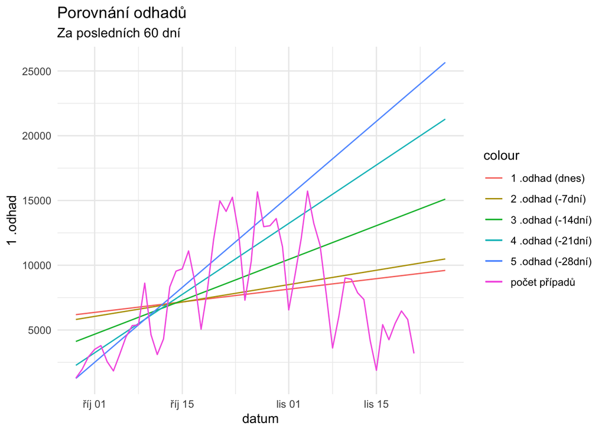

### Data (Lineární model)

#### Od začátku epidemie

Podle lineárního modelu bychom tímto tempem měli dne `2020-11-26` podle

- 1. odhadu `5497` nakažených denně
- 2. odhadu `5521` nakažených denně
- 3. odhadu `5548` nakažených denně
- 4. odhadu `5248` nakažených denně
- 5. odhadu `4415` nakažených denně

#### Za posledních `60` dní

Podle lineárního modelu bychom tímto tempem měli dne `2020-11-26` podle

- 1. odhadu `9600` nakažených denně
- 2. odhadu `10484` nakažených denně
- 3. odhadu `15105` nakažených denně
- 4. odhadu `21283` nakažených denně
- 5. odhadu `25659` nakažených denně

## Kvadratický model

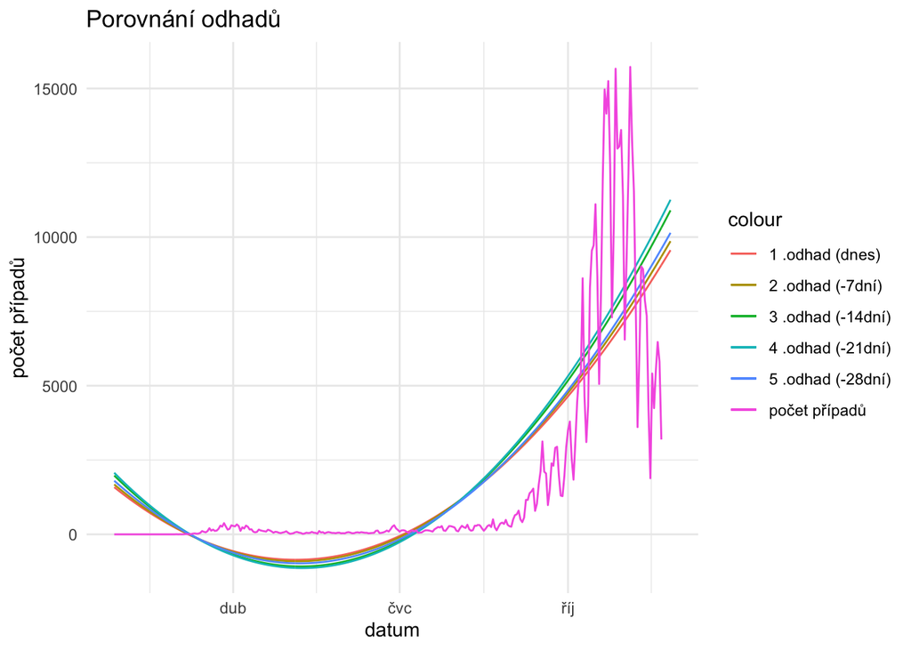

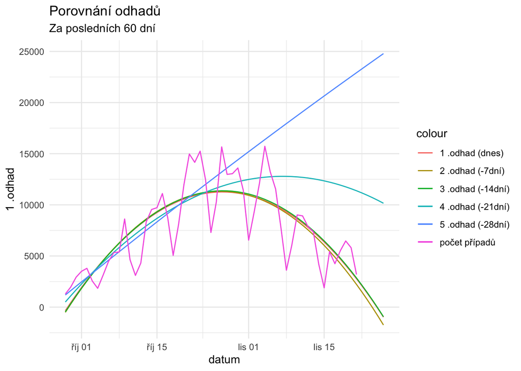

### Data (Kvadratický model)

#### Od začátku epidemie

Podle kvadratického modelu bychom tímto tempem měli dne `2020-11-26` podle

- 1. odhadu `9561` nakažených denně
- 2. odhadu `9862` nakažených denně
- 3. odhadu `10900` nakažených denně
- 4. odhadu `11256` nakažených denně
- 5. odhadu `10143` nakažených denně

#### Za posledních `60` dní

- 1. odhadu `-976` nakažených denně
- 2. odhadu `-1745` nakažených denně
- 3. odhadu `-939` nakažených denně
- 4. odhadu `10157` nakažených denně
- 5. odhadu `24786` nakažených denně

## Exponential model

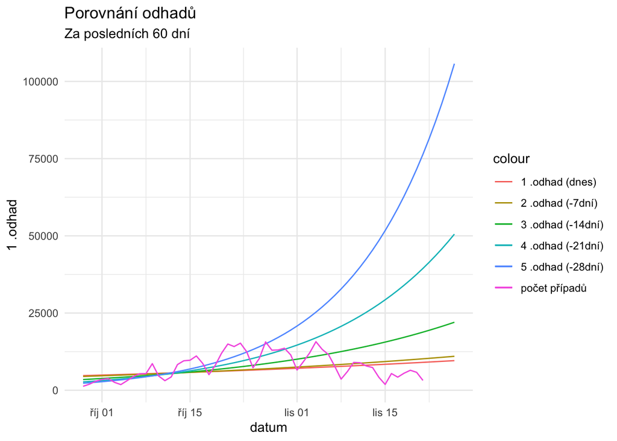

### Data (Exponential model)

#### Za posledních `60` dní

Podle exponencionálního modelu bychom tímto tempem měli dne `2020-11-26` podle

- 1. odhadu `9594` nakažených denně
- 2. odhadu `10994` nakažených denně
- 3. odhadu `22016` nakažených denně
- 4. odhadu `50544` nakažených denně
- 5. odhadu `105726` nakažených denně

Podle exponencionálního modelu bychom tímto tempem měli dnes dne `2020-11-22` podle

- 1. odhadu `9146` nakažených denně
- 2. odhadu `10344` nakažených denně
- 3. odhadu `19423` nakažených denně
- 4. odhadu `41447` nakažených denně
- 5. odhadu `81510` nakažených denně

# Informace

Update proběhl `2020-11-22 23:11:39`.

Poslední data jsou z `2020-11-21` ze stránek ministerstva zdravotnictví ČR (https://onemocneni-aktualne.mzcr.cz/covid-19)